# Animate a choropleth

Feasibility of a slider filter

John Little

2019-03-13

Backdrop: I spent several hours trying to use the `crosstalk` or `plotly` packages to generate a suitable choropleth with a slider filter. The purpose of the slider filter should enable filtering by year so the end-user can see change over time. In practice this proved to be unfeasible or unworkable. The animation transitions were sloppy or goofy; the slider wouldn’t work as expected. In short the idea proved much easier than the execution.

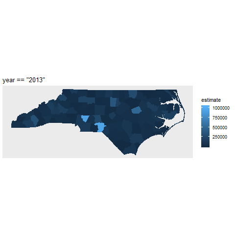

However, the resulting investigation show me several aspects about the practical execution of showing change over time. I am shorthand documenting some of those issues here.

## Load Library Packages

First, let’s load the necessary packages.

```r
library(tidyverse)
library(tidycensus)
library(sf)
library(gganimate)
```

## Get Data

Now let’s get some ACS Census data and then scramble the data. By scramble what I mean is randomize the data so that it’s easier to see the changes over time. Since the data re scrambled, there’s really no need to know what the actual census variable means, but I’m pretty sure I started with population for North Carolina covering 2013 - 2016.

```r
nc_2016 <-
  get_acs(geography = "county",
          variables = "B01003_001",
          state = "NC",
          geometry = TRUE,
          cache_table = TRUE) %>%
  mutate(year = "2016")

nc_2015 <-
  get_acs(geography = "county",
          variables = "B01003_001",
          state = "NC",
          year = 2015,
          geometry = TRUE,
          cache_table = TRUE) %>%
  mutate(year = "2015")

nc_2014 <-
  get_acs(geography = "county",
          variables = "B01003_001",
          state = "NC",
          year = 2014,
          geometry = TRUE,
          cache_table = TRUE) %>%
  mutate(year = "2014")

nc_2013 <-
  get_acs(geography = "county",
          variables = "B01003_001",
          state = "NC",
          year = 2013,
          geometry = TRUE,
          cache_table = TRUE) %>%
  mutate(year = "2013")
```

## Wrangle Data

Combine the small tables into a big table. Make a copy of the same with scrambled data via `sample()`. Additionally, make a scrambled table without sf geometry for use in the bar plot.

```r
big_table <- rbind(nc_2016, nc_2015, nc_2014, nc_2013)

nc_2016_r <- nc_2016
nc_2015_r <- nc_2015
nc_2014_r <- nc_2014
nc_2013_r <- nc_2013

nc_2016_r$estimate <- sample(nc_2016_r$estimate)
nc_2015_r$estimate <- sample(nc_2015_r$estimate)
nc_2014_r$estimate <- sample(nc_2014_r$estimate)
nc_2013_r$estimate <- sample(nc_2013_r$estimate)

bg_r <- rbind(nc_2016_r, nc_2015_r, nc_2014_r, nc_2013_r)

bg_r_nogeom <- bg_r
sf::st_geometry(bg_r_nogeom) <- NULL  # remove geometry layer from the SF Tibble

bg_r_small <- bg_r %>%
  mutate(county = str_extract(NAME, "\\w+")) %>%
  filter(county == "Orange" |
         county == "Wake" |
         county == "Durham")

nc_2013_r_small <- nc_2013_r %>%
  mutate(county = str_extract(NAME, "\\w+")) %>%
  filter(county == "Orange" |
         county == "Wake" |
         county == "Durham")

nc_2014_r_small <- nc_2013_r %>%
  mutate(county = str_extract(NAME, "\\w+")) %>%
  filter(county == "Orange" |
         county == "Wake" |
         county == "Durham")


nc_2015_r_small <- nc_2013_r %>%
  mutate(county = str_extract(NAME, "\\w+")) %>%
  filter(county == "Orange" |
         county == "Wake" |
         county == "Durham")


nc_2016_r_small <- nc_2013_r %>%
  mutate(county = str_extract(NAME, "\\w+")) %>%
  filter(county == "Orange" |
         county == "Wake" |
         county == "Durham")

nc_2016_r_small$estimate <-
  sample(nc_2016_r_small$estimate)
nc_2015_r_small$estimate <-
  sample(nc_2015_r_small$estimate)
nc_2014_r_small$estimate <-
  sample(nc_2014_r_small$estimate)
nc_2013_r_small$estimate <-
  sample(nc_2013_r_small$estimate)
```

## Facet Map

Facet Maps are amazingly effective at showing change. Perhaps this is actually better than animating. It’s certainly far less work using the `facet_wrap()` function. A benefit of a facet wrap is the ability to see all the data at one time. This makes comparisons across non-consecutive views easier to perceive.

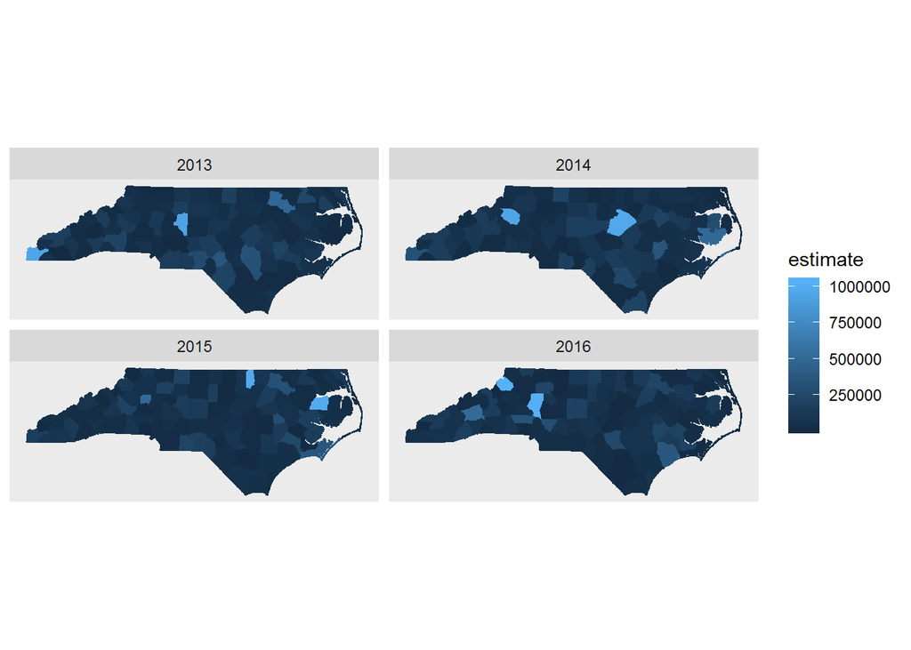

```r
ggplot(bg_r) +
  geom_sf(aes(fill = estimate, color = estimate)) +
  coord_sf(crs = 4326, datum = NA) +
  facet_wrap(~year)
```

## Bar Plots

Sometimes geography is not the best way to showcase data, **even when the data have a geographical element**. The next plot visualizes the change over time for three counties in a side-by-side bar graph. The change over time is much more obvious when the yearly amount for relevant counties are positioned next to each other.

Side-by-side bar graphs are a ggplot option using `position = "dodge"`.

A time-change question that is easier to answer with a bar graph than a choropleth is as follows: *Which county has the highest annual amount for the year 2014?*. Compare this question by looking at the choropleth facet map above and the bar graph below.

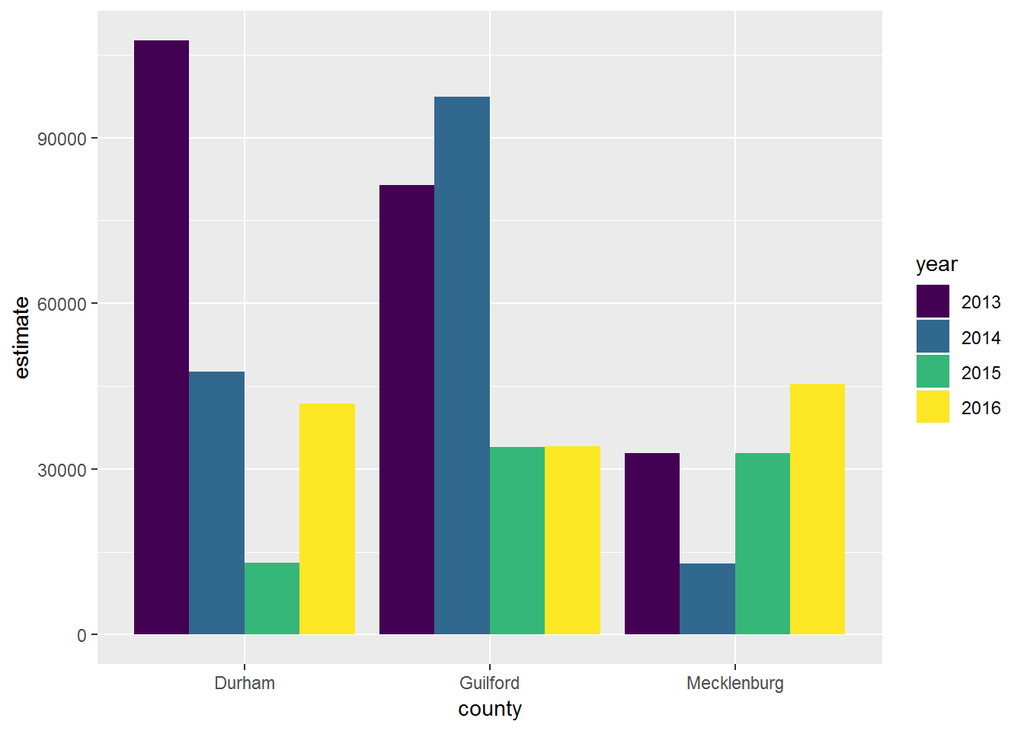

Highest County for 2014?

```r
bg_r_nogeom %>%
  mutate(county = str_extract(NAME, "\\w+")) %>%
  filter(county == "Mecklenburg" |
           county == "Durham" |
           county == "Guilford") %>%
  select(county, estimate, year) %>%
  gather("foo", "year", -county, -estimate) %>%
  ggplot() +
  geom_col(aes(x = county, y = estimate, fill = year),
           position = "dodge") +
  scale_fill_viridis_d()
```

## Animate

First the whole of North Carolina. This takes some CPU processing time.

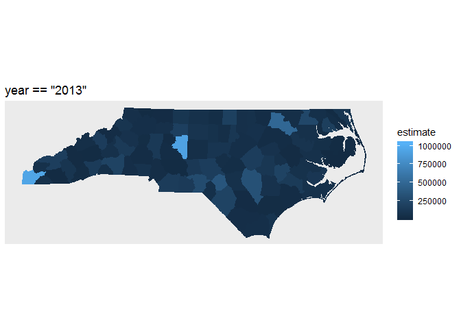

```r
p <- ggplot(bg_r) +
  geom_sf(aes(fill = estimate, color = estimate)) +
  coord_sf(datum = NA) +
  labs(title = '{next_expression}') +
  transition_filter(transition_length = 0.4,
                    filter_length = 0.4,
                    year == "2013",
                    year == "2014",
                    year == "2015",
                    year == "2016") +
  enter_fade() +
  exit_fade() +
  shadow_mark(past = TRUE, future = TRUE)

animate(p)
```

Let’s do a subset of counties. It’s quicker. The main point of this animation is to transform the text label with the stringr package. It seems a bit overwrought but it works.

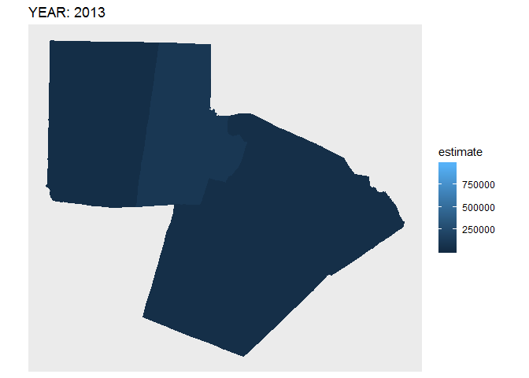

Better Title. i.e. label variables

```r
pcounty <- ggplot(bg_r_small) +
  geom_sf(aes(fill = estimate, color = estimate)) +
  coord_sf(datum = NA) +
  labs(title = "YEAR: {str_replace_all(str_replace(as.character(next_expression), 'year == ', ''), '\"', '')}") +
  transition_filter(transition_length = 0.4,
                    filter_length = 0.4,
                    year == "2013",
                    year == "2014",
                    year == "2015",
                    year == "2016") +
  enter_fade() +
  exit_fade() +
  shadow_mark(past = TRUE, future = TRUE)


animate(pcounty)
```

```r
anim_save("county_trans_filter.png")
```

## Tableau Slider

Or you can do this with Tableau. Lots to discuss about this approach but I’ll leave the verbiage for later.

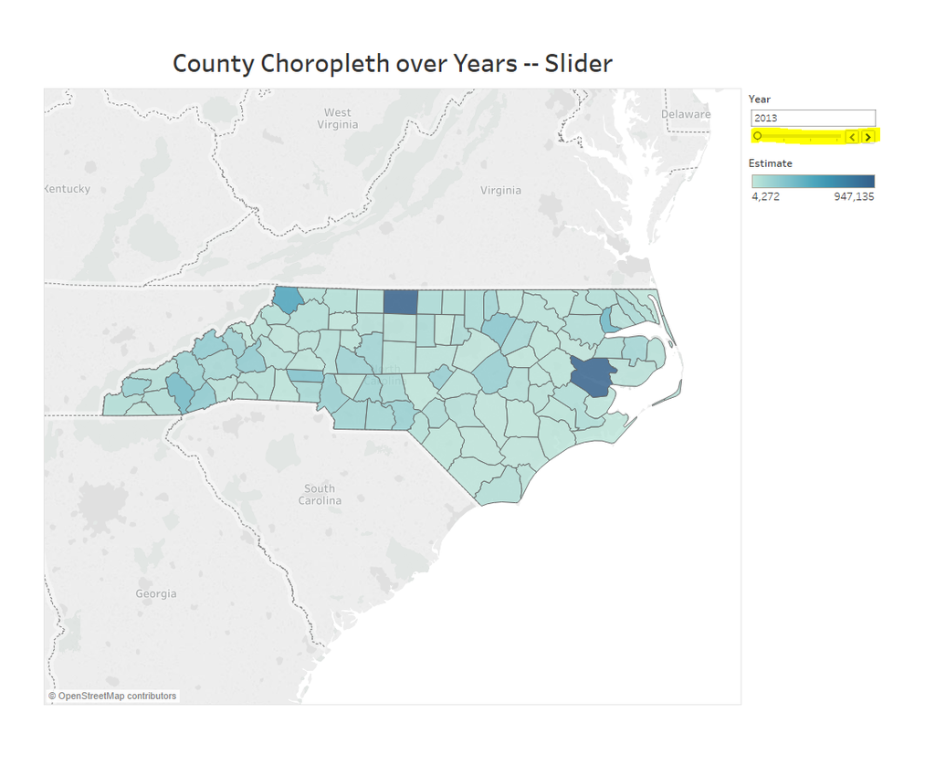

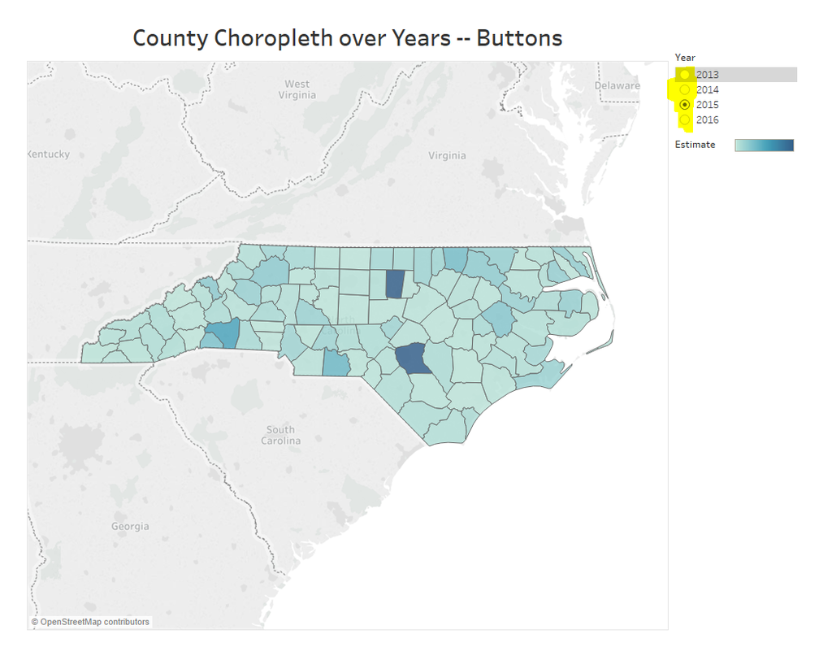